**Recurrent Neural Network**

By Prof. Seungchul Lee  
http://iai.postech.ac.kr/  
Industrial AI Lab at POSTECH

Table of Contents

# 1. Recurrent Neural Network (RNN)

- RNNs are a family of neural networks for processing sequential data

## 1.1. Feedforward Network and Sequential Data

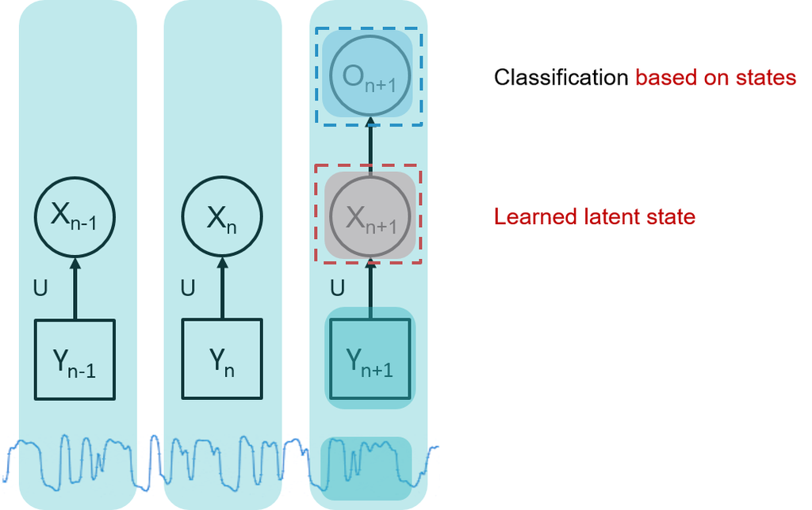

- Separate parameters for each value of the time index
- Cannot share statistical strength across different time indices

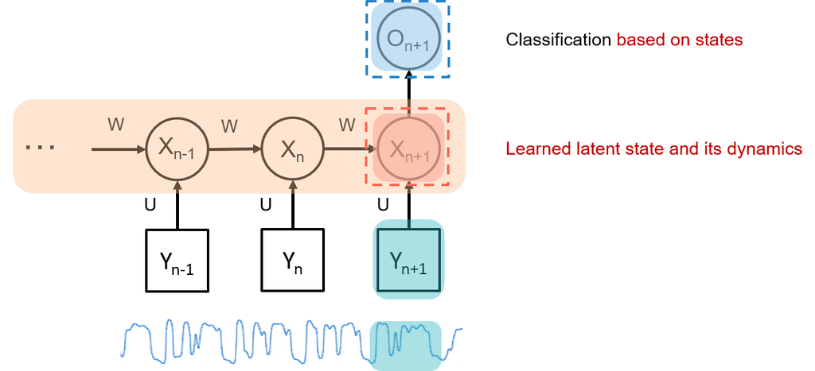

```python
%%html
<center><iframe src="https://www.youtube.com/embed/oYglxfBtSQk?rel=0"
width="560" height="315" frameborder="0" allowfullscreen></iframe></center>
```

[video not shown]

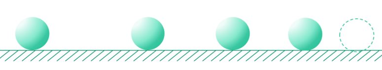

## 1.2. Representation Shortcut

- Input at each time is a vector
- Each layer has many neurons
- Output layer too may have many neurons
- But will represent everything simple boxes
- Each box actually represents an entire layer with many units

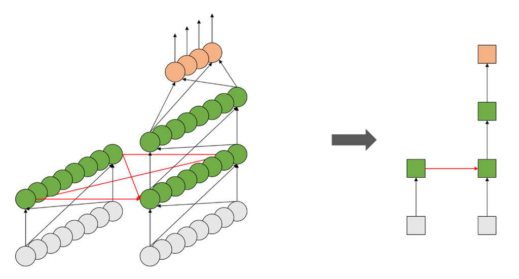

## 1.3. Finite-Response Model

- Something that happens today only affects the output of the system for $N$ days into the future
- $N$ is the width of the system

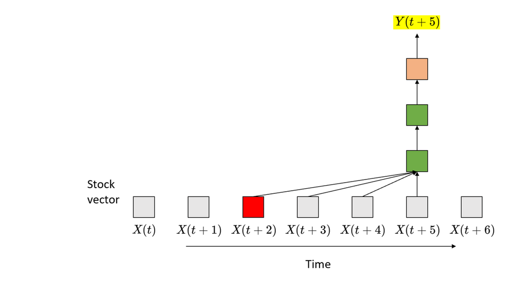

- Problem: Increasing the “history” makes the network more complex

$$Y_t = f\left(X_t, X_{t-1}, \cdots, X_{t - N} \right)$$

## 1.4. In Theory, We Want Infinite Memory

- Required: Infinite response systems
  - What happens today can continue to affect the output forever
  - Possibly with weaker and weaker influence

$$Y_t = f\left(X_t, X_{t-1}, \cdots, X_{t - \infty} \right)$$

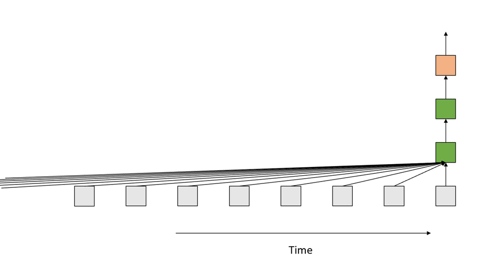

- Recursive
  - Output contains information about the entire past

$$Y_t = f\left(X_t, X_{t-1}, \cdots, X_{t - \infty} \right) \quad \Longrightarrow \quad Y_t = f\left(X_t, Y_{t-1} \right)$$

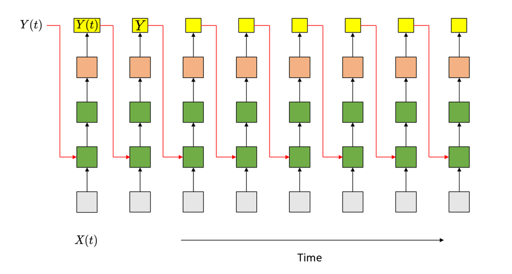

## 1.5. An Alternate Model for Infinite Response Systems

- The state-space model

$$ \begin{align*} h_t &= f(x_t, h_{t-1})\\ y_t &= g(h_t) \end{align*} $$

- This is a recurrent neural network
- State summarizes information about the entire past
- Single Hidden Layer RNN (Simplest State-Space Model)

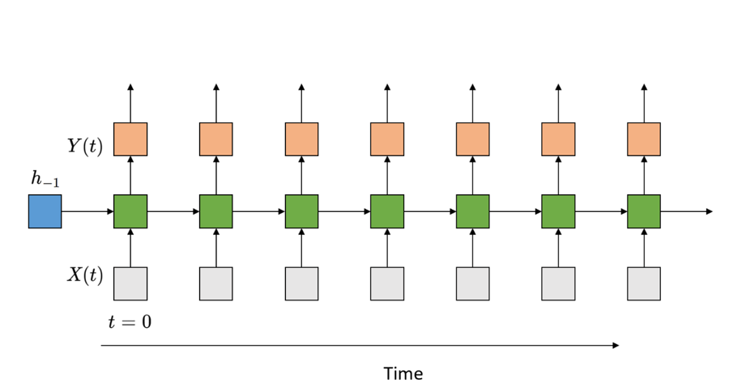

- Multiple Recurrent Layer RNN

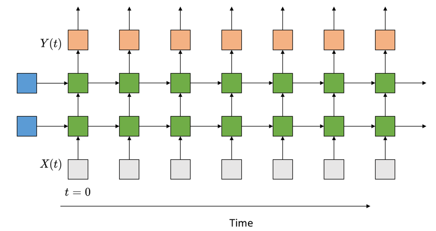

- Recurrent Neural Network
  - Simplified models often drawn
  - The loops imply recurrence

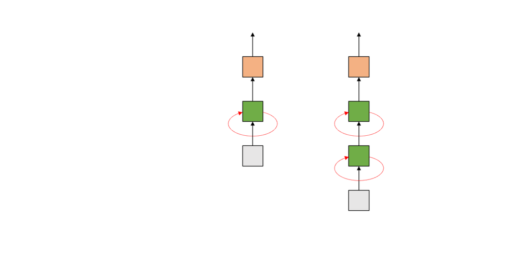

## 1.6. Feedforward Propagtion

- This is a RNN where the input and output sequences are of the same length
- Feedforward operation proceeds from left to right
- Update Equations:

$$ \begin{align*} a_t &= b + W h_{t-1} + U x_t\\ h_t &= \tanh a_t\\ o_t &= c + V h_t \\ \hat{y}_t & = \text{softmax}(o_t) \end{align*} $$

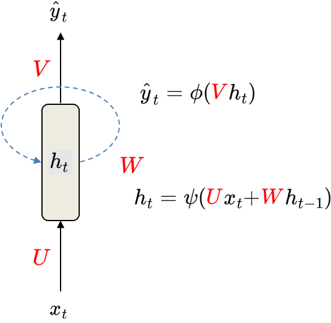

## 1.7. Backward Propagation

- Loss would just be the sum of losses over time steps
- Treat the recurrent network as a usual multilayer network and apply backpropagation on the unrolled network
- This is called Backpropagation through time (BPTT)

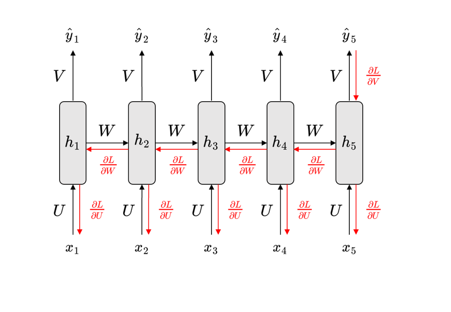

# 2. LSTM Networks

## 2.1. Long-Term Dependencies

- Gradients propagated over many stages tend to either **vanish** or **explode**
- Difficulty with long-term dependencies arises from the exponentially smaller weights given to long-term interactions
- Introduce a memory state that runs through only linear operators
- Use gating units to control the updates of the state

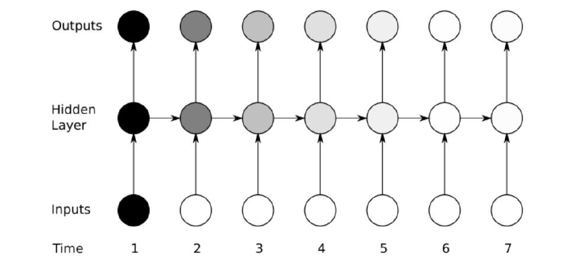

Example: "I grew up in France… I speak fluent *French*."

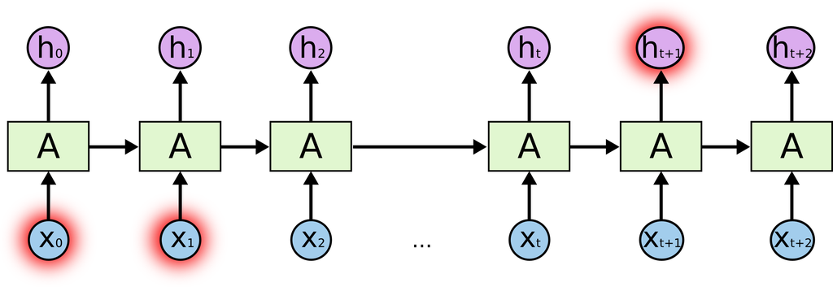

## 2.2. Long Short-Term Memory (LSTM)

- Consists of a memory cell and a set of gating units
  - Memory cell is the context that carries over
  - Forget gate controls erase operation
  - Input gate controls write operation
  - Output gate controls the read operation

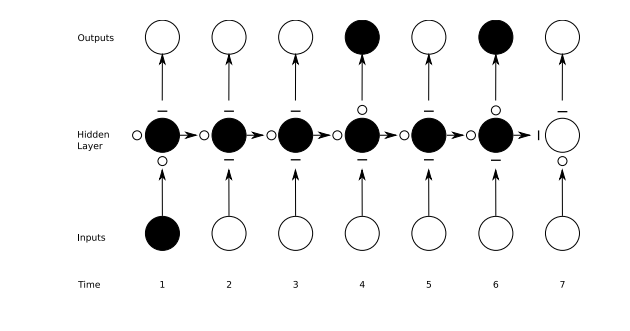

- Connect LSTM cells in a recurrent manner
- Train parameters in LSTM cells

## 2.3. Gating

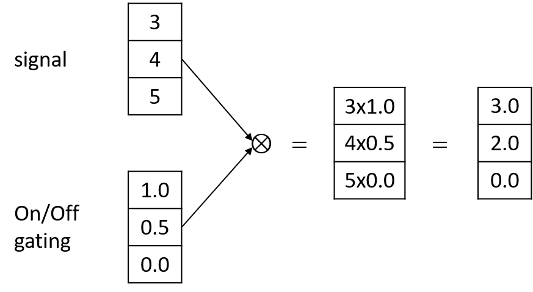

## 2.4. LSTM

- https://elham-khanche.github.io/blog/RNNs_and_LSTM/

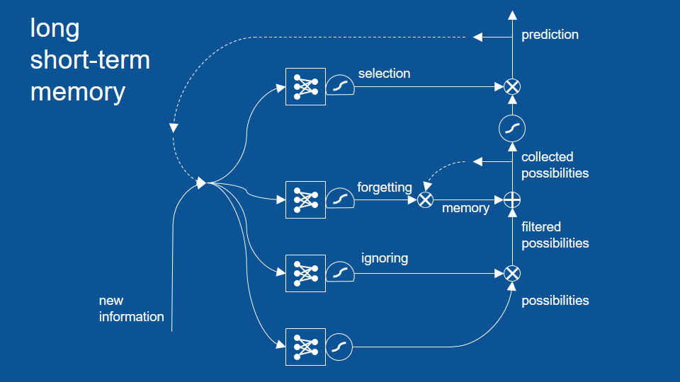

By Michael Nguyen

```python
%%html
<center><iframe src="https://www.youtube.com/embed/8HyCNIVRbSU?rel=0"
width="560" height="315" frameborder="0" allowfullscreen></iframe></center>
```

[video not shown]

By colah's blog

- http://colah.github.io/posts/2015-08-Understanding-LSTMs/

### 2.4.1. LSTM for Classification

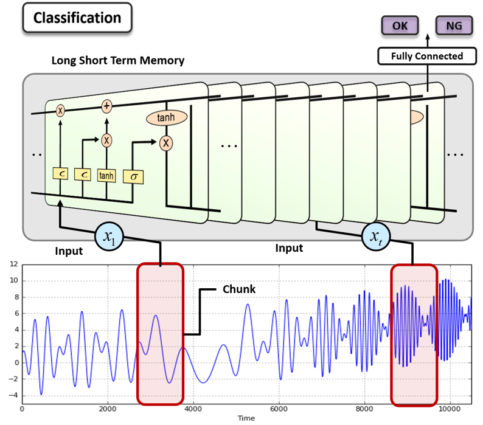

### 2.4.2. LSTM for Prediction

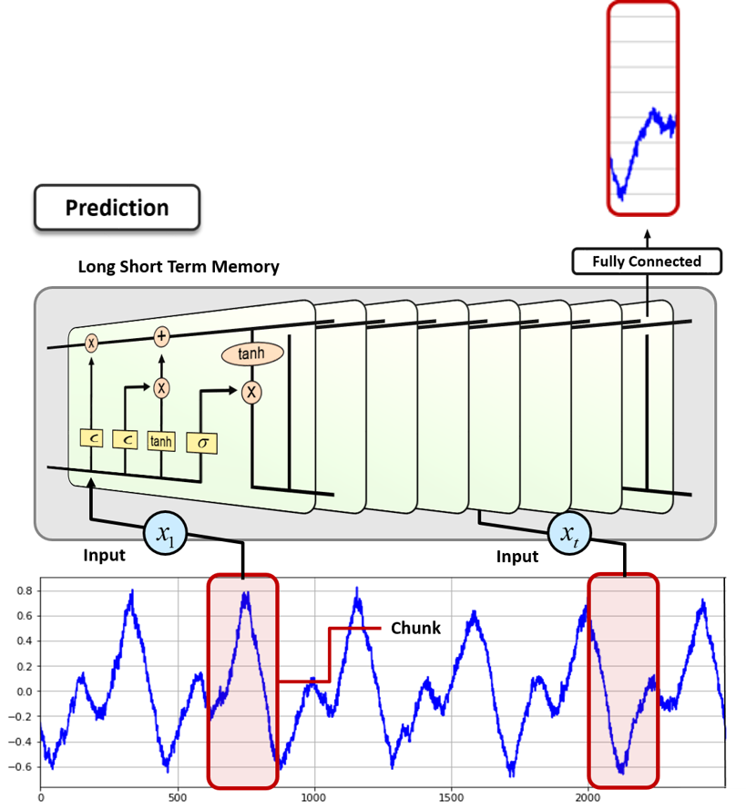

# 3. LSTM with TensorFlow

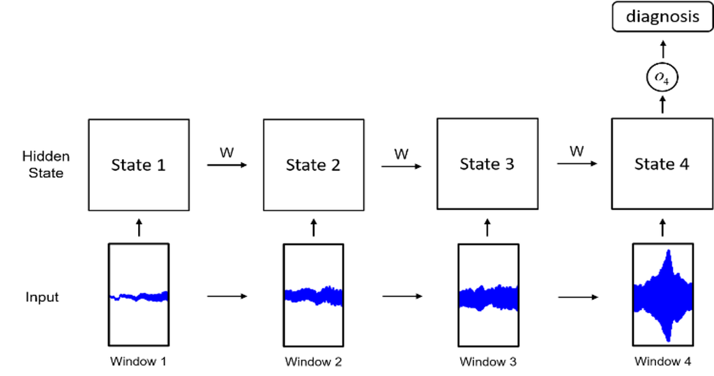

## 3.1. Import Library

```python
import tensorflow as tf
from six.moves import cPickle
import numpy as np
import matplotlib.pyplot as plt
```

- Import acceleration signal of rotation machinery
- Download [files](https://www.dropbox.com/s/42dic65cf17o0eu/rnn_time_signal.pkl?dl=1)

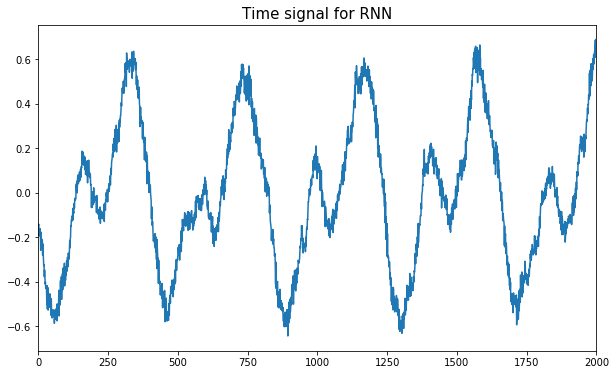

```python
data =  cPickle.load(open('./data_files/rnn_time_signal.pkl', 'rb'))

plt.figure(figsize=(10,6))
plt.title('Time signal for RNN', fontsize=15)
plt.plot(data[0:2000])
plt.xlim(0,2000)
plt.show()
```

## 3.3. Define RNN Structure

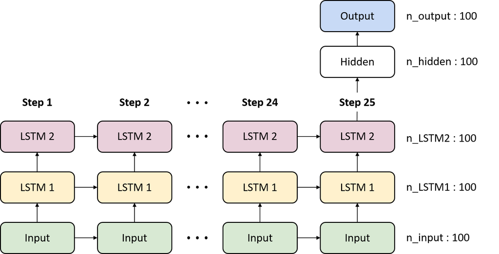

```python
n_step = 25
n_input = 100

## LSTM shape
n_lstm1 = 100
n_lstm2 = 100

## Fully connected
n_hidden = 100
n_output = 100
```

## 3.4. Define Weights and Biases

**LSTM Cell**

- Do not need to define weights and biases of LSTM cells

**Fully connected**

- Define parameters based on the predefined layer size
- Initialize with a normal distribution with $\mu = 0$ and $\sigma = 0.01$

```python
weights = {
    'hidden' : tf.Variable(tf.random_normal([n_lstm2, n_hidden], stddev = 0.01)),
    'output' : tf.Variable(tf.random_normal([n_hidden, n_output], stddev = 0.01))
}

biases = {
    'hidden' : tf.Variable(tf.random_normal([n_hidden], stddev = 0.01)),
    'output' : tf.Variable(tf.random_normal([n_output], stddev = 0.01))
}

x = tf.placeholder(tf.float32, [None, n_step, n_input])
y = tf.placeholder(tf.float32, [None, n_output])
```

## 3.5. Build a Model

**Build the RNN Network**

- First, define the LSTM cells

```
lstm = tf.nn.rnn_cell.LSTMCell(n_lstm)
```

- Second, compute hidden state (h) and lstm cell (c) with the predefined lstm cell and input

```
h, c = tf.nn.dynamic_rnn(lstm, input_tensor, dtype = tf.float32)
```

```python
def build_model(x, weights, biases):
    with tf.variable_scope('rnn'):
        # Build RNN network
        with tf.variable_scope('lstm1'):
            lstm1 = tf.nn.rnn_cell.LSTMCell(n_lstm1)
            h1, c1 = tf.nn.dynamic_rnn(lstm1, x, dtype = tf.float32)
        with tf.variable_scope('lstm2'):
            lstm2 = tf.nn.rnn_cell.LSTMCell(n_lstm2)
            h2, c2 = tf.nn.dynamic_rnn(lstm2, h1, dtype = tf.float32)

        # Build classifier
        hidden = tf.add(tf.matmul(h2[:,-1,:], weights['hidden']), biases['hidden'])
        hidden = tf.nn.relu(hidden)
        output = tf.add(tf.matmul(hidden, weights['output']), biases['output'])
        return output
```

## 3.6. Define Cost, Initializer and Optimizer

Loss

- Regression: Squared loss

$$ \frac{1}{N} \sum_{i=1}^{N} (\hat{y}^{(i)} - y^{(i)})^2$$

Initializer

- Initialize all the empty variables

Optimizer

- AdamOptimizer: the most popular optimizer

```python
LR = 0.0001

pred = build_model(x, weights, biases)
loss = tf.square(tf.subtract(y, pred))
loss = tf.reduce_mean(loss)

optm = tf.train.AdamOptimizer(LR).minimize(loss)
init = tf.global_variables_initializer()

sess = tf.Session()
```

[output not shown]

## 3.7. Summary of Model

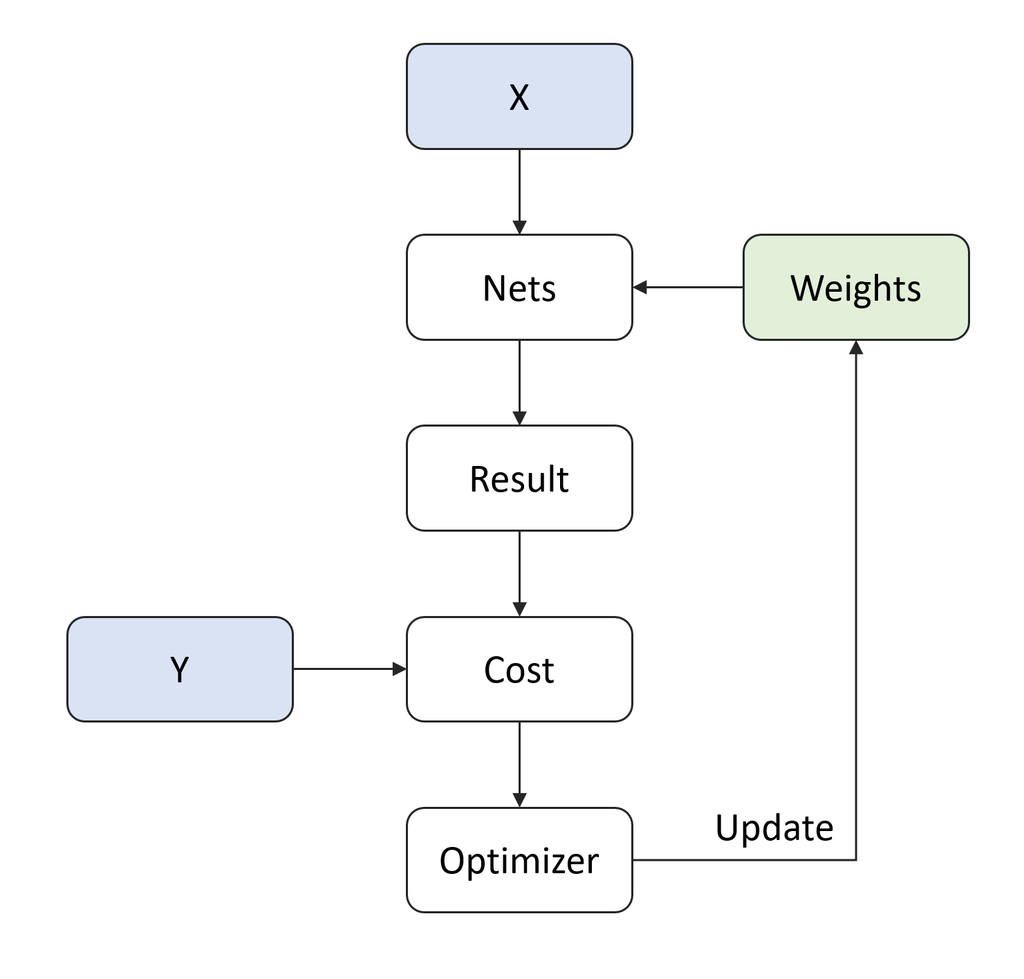

## 3.8. Define Optimization Configuration and Then Optimize

- Define parameters for training RNN
  - `n_iter`: the number of training steps
  - `n_prt`: check loss for every `n_prt` iteration

```python
n_iter = 5000
n_prt = 250
stride = 5
```

```python
# Run initialize
sess.run(init)

for i in range(n_iter):
    train_x = data[i*stride:i*stride + n_step*n_input]
    train_x = train_x.reshape(n_step, n_input)
    train_x = train_x[np.newaxis, :]

    train_y = data[i*stride + n_step*n_input:i*stride + n_step*n_input + n_output]
    train_y = train_y[np.newaxis, :]

    sess.run(optm, feed_dict = {x: train_x,  y: train_y})
    c = sess.run(loss, feed_dict = {x: train_x,  y: train_y})
    if i % n_prt == 0:
        print ("Iter : {}".format(i))
        print ("Cost : {}".format(c))
```

```
Iter : 0
Cost : 0.18581759929656982
Iter : 250
Cost : 0.19313396513462067
Iter : 500
Cost : 0.24150621891021729
Iter : 750
Cost : 0.18231706321239471
Iter : 1000
Cost : 0.24338026344776154
Iter : 1250
Cost : 0.18947656452655792
Iter : 1500
Cost : 0.0504690445959568
Iter : 1750
Cost : 0.019232742488384247
Iter : 2000
Cost : 0.006845887750387192
Iter : 2250
Cost : 0.01760091818869114
Iter : 2500
Cost : 0.0020267204381525517
Iter : 2750
Cost : 0.008779379539191723
Iter : 3000
Cost : 0.015404012985527515
Iter : 3250
Cost : 0.019550597295165062
Iter : 3500
Cost : 0.0046103354543447495
Iter : 3750
Cost : 0.006338868755847216
Iter : 4000
Cost : 0.005829943809658289
Iter : 4250
Cost : 0.0016335052205249667
Iter : 4500
Cost : 0.004191332962363958
Iter : 4750
Cost : 0.014816559851169586
```

## 3.9. Test or Evaluate

- Predict future time signal

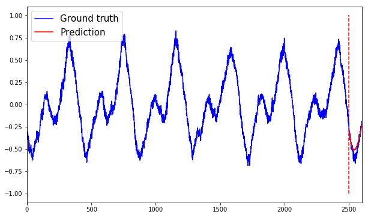

```python
test_x = data[10000:10000 + n_step*n_input]
test_x = test_x.reshape(n_step, n_input)
test_x = test_x[np.newaxis, :]

ground_truth = data[10000:10000 + n_step*n_input + n_input]

test_pred = sess.run(pred, feed_dict = {x: test_x})

plt.figure(figsize=(10,6))
plt.plot(np.arange(0, n_step*n_input + n_input), ground_truth, 'b', label = 'Ground truth')
plt.plot(np.arange(n_step*n_input, n_step*n_input + n_input), test_pred.ravel(), 'r', label = 'Prediction')
plt.vlines(n_step*n_input, -1, 1, colors = 'r', linestyles = 'dashed')
plt.legend(fontsize = 15, loc = 'upper left')
plt.xlim(0, len(ground_truth))
plt.show()
```

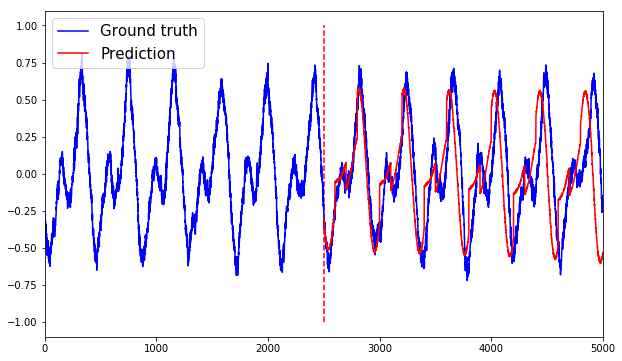

```python
test_x = data[10000:10000 + n_step*n_input]
test_x = test_x.reshape(n_step, n_input)
test_x = test_x[np.newaxis, :]

ground_truth = data[10000:10000 + n_step*n_input + n_step*n_input]

gen_signal = []
for i in range(n_step):
    test_pred = sess.run(pred, feed_dict = {x: test_x})
    gen_signal.append(test_pred.ravel())
    test_pred = test_pred[:, np.newaxis, :]

    test_x = test_x[:, 1:, :]
    test_x = np.concatenate([test_x, test_pred], axis = 1)

gen_signal = np.concatenate(gen_signal)

plt.figure(figsize=(10,6))
plt.plot(np.arange(0, n_step*n_input + n_step*n_input), ground_truth, 'b', label = 'Ground truth')
plt.plot(np.arange(n_step*n_input,  n_step*n_input + n_step*n_input), gen_signal, 'r', label = 'Prediction')
plt.vlines(n_step*n_input, -1, 1, colors = 'r', linestyles = 'dashed')
plt.legend(fontsize=15, loc = 'upper left')
plt.xlim(0, len(ground_truth))
plt.show()
```

# 5. Other Tutorials

MIT

```python
%%html
<center><iframe src="https://www.youtube.com/embed/_h66BW-xNgk?rel=0"
width="560" height="315" frameborder="0" allowfullscreen></iframe></center>
```

[video not shown]

CMU

```python
%%html
<center><iframe src="https://www.youtube.com/embed/FgwjF6rCsz8?rel=0"
width="560" height="315" frameborder="0" allowfullscreen></iframe></center>
```

[video not shown]

Stanford

```python
%%html
<center><iframe src="https://www.youtube.com/embed/6niqTuYFZLQ?rel=0"
width="560" height="315" frameborder="0" allowfullscreen></iframe></center>
```

[video not shown]

```python
%%javascript
$.getScript('https://kmahelona.github.io/ipython_notebook_goodies/ipython_notebook_toc.js')
```